# Deep Q Learning with Flappy Bird

# Batch learning

The network trains on mini batch of size 32 instead of the full dataset for each run. This allows to reduce calculation time.

# Injecting Random Action

Thinking intuitively, we learn much more from new experiences than the usual experiences. In effort to apply this concept into network training, we force the network to try random actions once in a while, especially in the early stage of learning. Therefore I set the probability of bird performing a random action as 0.1 and slowly decreased it down to 0.0001 over 2 million time frame. This will stimulate training by injecting in random actions, which can function as the “new experience”.

# Analysis of learning pattern

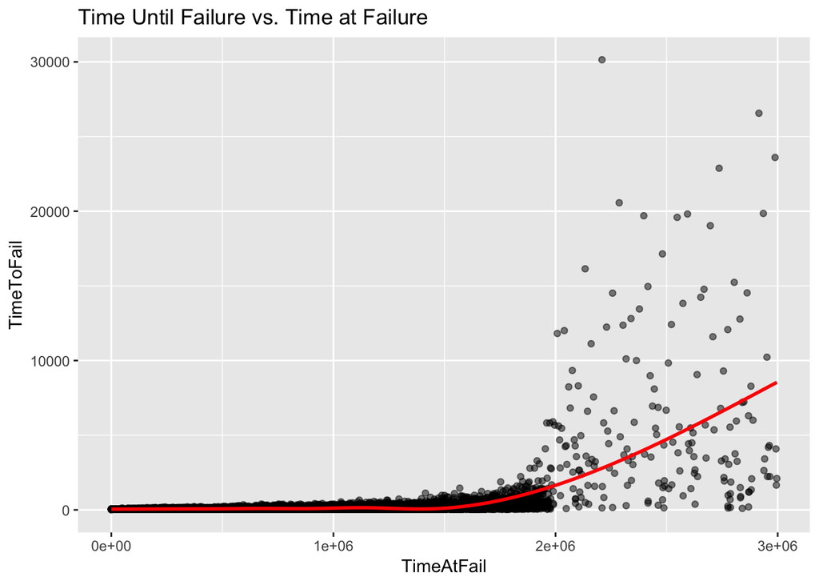

```r
library(ggplot2)
time_to_fail <- read.csv("time_to_fail.csv")
colnames(time_to_fail) <- c("X", "TimeAtFail")

time_to_fail$TimeToFail <- c(0,diff(time_to_fail$TimeAtFail))



ggplot(data = time_to_fail, aes(x=TimeAtFail, y=TimeToFail)) +
  geom_point(alpha = 0.5) +
  geom_smooth(se = FALSE, col = "red") +
  labs(title = "Time Until Failure vs. Time at Failure")
```

# Future Application

After understanding the concept of deep Q learning, applying this methods to train on other game is also possible. Take, for example, a famous game Mario. Mario has 4 possible actions: Left, Right, Jump, and Duck. We can train the network to play Mario by changing the dimension of the Q vector to have Q-scores for each actions in Mario. Other games like StarCraft, or any games that require mouse input may be harder. The number of possible actions will be extremely large, leading to high computational costs, thus requiring to train on multiple GPUs or server.

# Sources

This project was inspired by Yen Chen Lin’s open source project at https://github.com/yenchenlin/DeepLearningFlappyBird